# Single Cell Exercise: Day 2

#### Output files: -o

We use `-o` to designate a folder for the output quant files. At the beginning of this notebook, we used `mkdir` command to create this. Copy and paste only the file path from that command here.

```
# Write out the file path to the directory you created for your alevin quantification output files.
data/tabula-muris/alevin-quant/10X_P7_0
# This will be your -o option specification.
```

Write out a `dir.exists()` test to check if the directory you specified above exists. (Hint: Copy and paste the directory path exactly so you don’t accidentally introduce a typo to your test).

```r
# In this R code chunk, we can test if the directory we specified above is legitimate by using `dir.exist()` function.
# Use dir.exists() to check for your R1 file
dir.exists("data/tabula-muris/alevin-quant/10X_P7_0")
```

#### Transcript to gene file: –tgMap

We use `--tgMap` to supply a transcript to gene key that alevin will use to quantify the genes. This specification will go hand-in-hand with the transcriptome index you are using. In this case, we are using the same transcriptome index we used in `04-tag-based_scRNA-seq_processing.Rmd`; so we will also use the same transcript to gene key file as well. You’ll find this file in the `data/tabula-muris` folder.

```
# Write out the file path to the directory you created for your alevin quantification output files.
data/tabula-muris/mm_ensdb95_tx2gene.tsv
# This will be your --tgMap option specification.
```

#### Flags we’ll need!

*–chromium*: Because we are using 10X Chromium data again, we need to use the `--chromium` flag in our command! (If we were using DropSeq data, we’d use a `--dropseq` flag instead of this).

*–dumpFeatures*: `alevinQC` depends on files that we get by using this option; so need this flag in our command as well!

### Put our Alevin command altogether and run it!

Remember that when we need a command to continue on to the next line, we end it with `\`.

Here we’ve got a template of what your alevin quant command will look like. In the previous steps, we determined what each of these should be. Note that when we need a command to continue on to the next line, we end it with `\`.

**Template alevin command**

```
salmon alevin \
  -l <library_type> \
  -i <transcriptome_index_file_path> \
  -1 <R1_file_path> \
  -2 <R2_file_path> \
  -o <output_file_path> \
  --tgMap <tx2gene_file_path> \
  --<some_flag> \
  --<some_other_flag> \
  -p 5
```

First, copy and paste this whole template (but not the backticks) into the code chunk we have below. Then, it is your task to replace every `<fill_in_the_blank>` with what you determined previously!

*Important tips as you fill in the blanks*:  
1) *Do* remove the `<` and `>`’s. 2) *Don’t* remove the `\`’s.  
3) *Don’t* touch the `-p` command at the end. We have preset this for you - it determines how many threads this command will be allowed.

[output not shown]

When you believe you have written in every option correctly, run the code chunk! If you have specified everything correctly, the quantification will run. This will take some time; when it is done the last message you will see is

```
[alevinLog] [info] Finished optimizer
```

### Perform QC checks with `alevinQC`

Now that we have quantified our data with Alevin, we are ready to perform quality control checks.

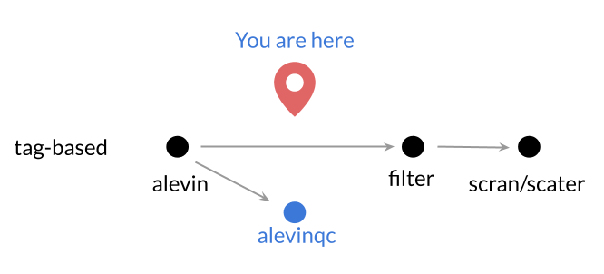

**Current status of this dataset**

In order to perform quality control checks, we’ll use the `alevinQC` R package. We have already constructed this command for you.

```r
# Produce a QC report
alevinQC::alevinQCReport("data/tabula-muris/alevin-quant/10X_P7_0",
                         sampleId = "10X_P7_0",
                         outputFile = "10X_P7_0_qc_report.html",
                         outputDir = "qc-reports")
```

Look for the `10X_P7_0_qc_report.html` file created in the `qc-reports` directory to examine the quality of your data and performance of Alevin.